# rPrattProj2

REILLY PRATT PROJECT2 edit: I know I messaed up an arithmetic function somewhere but the concepts are all here! I've tried to complete each part. Please dont be too harsh! ):

Problem 1

```python
import pandas
import sqlite3

sqlite_file = 'lahman2014.sqlite'
conn = sqlite3.connect(sqlite_file)

wasd = pandas.read_sql("SELECT yearID, teamID, G as total_games, W as total_wins FROM Teams GROUP BY yearID, teamID ORDER BY yearID DESC", conn)

wasd['average_win_%'] = ((wasd['total_wins'] / wasd['total_games'] ) * 100)

sal = pandas.read_sql("SELECT yearID, teamID, sum(salary) as total_salary FROM Salaries GROUP BY yearID, teamID ORDER BY yearID DESC", conn)

result = pandas.merge(wasd,sal, on=["yearID", "teamID"])

result2 = result.sort_values('total_salary', ascending=False)

print(result2)
```

```
     yearID teamID  total_games  total_wins  average_win_%  total_salary
47     2013    NYA          162          85      52.469136   231978886.0
43     2013    LAN          162          92      56.790123   223362196.0
13     2014    LAN          162          94      58.024691   217014600.0
287    2005    NYA          162          95      58.641975   208306817.0
197    2008    NYA          162          89      54.938272   207896789.0
..      ...    ...          ...         ...            ...           ...
844    1985    MIN          162          77      47.530864     5764821.0
778    1988    TEX          161          70      43.478261     5342131.0
853    1985    SEA          162          74      45.679012     4613000.0
801    1987    SEA          162          78      48.148148     2263500.0
804    1987    TEX          162          75      46.296296      880000.0

[858 rows x 6 columns]
```

Above is my SQL code for gathering the average win percentage of each team as well as the total $$$ spent on salary for the season. I have sorted the data from Salary going to high to low. There are in fact some discrepencies within the data, for example, the data from the Teams table goes back to 1871, while the data from the Salaries table only goes back to 1985.. This is an over 100 year gap of data missing. From the data you can see that average spending has increased over time.

Problem 2

```
   teamID  total_salary
0     ANA  4.680920e+08
1     ARI  1.209975e+09
2     ATL  1.810652e+09
3     BAL  1.569931e+09
4     BOS  2.365879e+09
5     CAL  2.032351e+08
6     CHA  1.655303e+09
7     CHN  1.791827e+09
8     CIN  1.385267e+09
9     CLE  1.364110e+09
10    COL  1.293911e+09
11    DET  1.708375e+09
12    FLO  6.750160e+08
13    HOU  1.348303e+09
```

[output cut: 23 more lines]

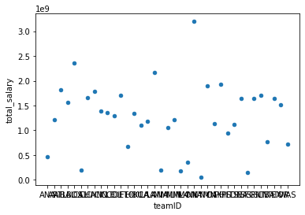

```python
sal2 = pandas.read_sql("SELECT teamID, sum(salary) as total_salary FROM Salaries WHERE yearID BETWEEN 1990 AND 2014 GROUP BY teamID", conn)
print(sal2)
sal2.plot.scatter("teamID", "total_salary")
```

Problem 3

```
    yearID  total_salary
29    2014  3.192318e+09
28    2013  3.034526e+09
27    2012  2.932741e+09
26    2011  2.784505e+09
25    2010  2.721360e+09
23    2008  2.684859e+09
24    2009  2.664727e+09
22    2007  2.476689e+09
21    2006  2.321473e+09
20    2005  2.188713e+09
18    2003  2.128262e+09
19    2004  2.070666e+09
17    2002  2.024078e+09
16    2001  1.960663e+09
```

[output cut: 16 more lines]

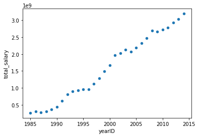

```python
sal3 = pandas.read_sql("SELECT yearID, sum(salary) as total_salary FROM Salaries GROUP BY yearID", conn)
result3 = sal3.sort_values('total_salary', ascending=False)
print(result3)
result3.plot.scatter("yearID", "total_salary")
```

Problem 4

```
           average_salary  average_win_%
bins
1985-1993    1.808074e+07      49.974002
1994-2001    4.466761e+07      49.977897
2002-2009    7.733111e+07      49.990217
2010-2016    9.644755e+07      49.999521
```

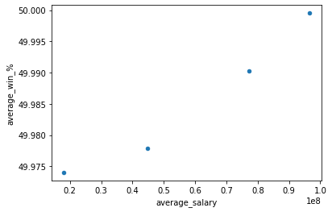

```python
result["bins"] = pandas.cut(x=result["yearID"], bins = [1984,1993,2001,2009,2016], labels=['1985-1993', '1994-2001', '2002-2009', '2010-2016'])

result4 = pandas.DataFrame()
result4["average_salary"] = result.groupby('bins')['total_salary'].mean()
result5 = pandas.DataFrame()
result5["average_win_%"] = result.groupby('bins')['average_win_%'].mean()

result6 = pandas.merge(result4,result5, on=["bins"])
print(result6)
result6.plot.scatter("average_salary", "average_win_%")
```

Problem 5

```python
prob6 = pandas.read_sql("SELECT yearID, teamID, sum(salary) as total_salary FROM Salaries GROUP BY yearID, teamID ORDER BY yearID DESC", conn)
prob7 = prob6.groupby('yearID').mean()
prob8 = pandas.merge(prob6,prob7, on=["yearID"])
prob8["standardized_payroll"] = (prob8["total_salary_y"] - prob8["total_salary_x"])/100
print(prob8)
```

```
     yearID teamID  total_salary_x  total_salary_y  standardized_payroll
0      2014    ARI      97861500.0    9.975993e+07          18984.257187
1      2014    ATL      97609000.0    9.975993e+07          21509.257187
2      2014    BAL     103416000.0    9.975993e+07         -36560.742813
3      2014    BOS     139019929.0    9.975993e+07        -392600.032813
4      2014    CHA      81830500.0    9.975993e+07         179294.257188
..      ...    ...             ...             ...                   ...
855    1985    SEA       4613000.0    1.007557e+07          54625.652308
856    1985    SFN       8221714.0    1.007557e+07          18538.512308
857    1985    SLN      11817083.0    1.007557e+07         -17415.177692
858    1985    TEX       7676500.0    1.007557e+07          23990.652308
859    1985    TOR       8812550.0    1.007557e+07          12630.152308

[860 rows x 5 columns]
```

Problem 6

```
           average_win_%  standardized_payroll
bins
1985-1993      49.974002           -584.547668
1994-2001      49.977897          -1608.565045
2002-2009      49.990217           4385.081022
2010-2016      49.999521          -3852.666067
```

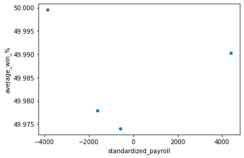

```python
result["bins"] = pandas.cut(x=result["yearID"], bins = [1984,1993,2001,2009,2016], labels=['1985-1993', '1994-2001', '2002-2009', '2010-2016'])
prob8["bins"] = pandas.cut(x=result["yearID"], bins = [1984,1993,2001,2009,2016], labels=['1985-1993', '1994-2001', '2002-2009', '2010-2016'])

resulty = pandas.DataFrame()
resulty["average_win_%"] = result.groupby('bins')['average_win_%'].mean()

resultx = pandas.DataFrame()
resultx["standardized_payroll"] = prob8.groupby('bins')['standardized_payroll'].mean()


resultz = pandas.merge(resulty, resultx, on=["bins"])
print(resultz)
resultz.plot.scatter("standardized_payroll", "average_win_%")
```

Question 3

So the standardized payroll variable shouldve given the payroll data a closer look at what the average payroll is per time period.

Problem 7

for the scatter plot needed for question 7, please look at the scatter plot in question 6 as it has the same axis'

Problem 8

```
     yearID teamID  total_salary_x  total_salary_y  standardized_payroll  \
0      2014    ARI      97861500.0    9.975993e+07          18984.257187
1      2014    ATL      97609000.0    9.975993e+07          21509.257187
2      2014    BAL     103416000.0    9.975993e+07         -36560.742813
3      2014    BOS     139019929.0    9.975993e+07        -392600.032813
4      2014    CHA      81830500.0    9.975993e+07         179294.257188
..      ...    ...             ...             ...                   ...
855    1985    SEA       4613000.0    1.007557e+07          54625.652308
856    1985    SFN       8221714.0    1.007557e+07          18538.512308
857    1985    SLN      11817083.0    1.007557e+07         -17415.177692
858    1985    TEX       7676500.0    1.007557e+07          23990.652308
859    1985    TOR       8812550.0    1.007557e+07          12630.152308

     expected_win_%  efficiency
0         54.746064  -15.239891
1         55.377314   -6.611882
2         40.859814   18.399445
3        -48.150008   91.977169
4         94.823564  -49.761836
..              ...         ...
855       63.656413   -1.310734
856       54.634628  -16.125311
857       45.646206   15.844478
858       55.997663         NaN
859       53.157538         NaN

[860 rows x 7 columns]
```

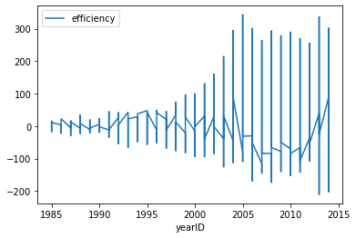

```python
pp1 = pandas.read_sql("SELECT yearID, teamID, sum(salary) as total_salary FROM Salaries GROUP BY yearID, teamID ORDER BY yearID DESC", conn)
pp2 = pp1.groupby('yearID').mean()
pp12 = pandas.merge(pp1,pp2, on=["yearID"])
pp12["standardized_payroll"] = (pp12["total_salary_y"] - pp12["total_salary_x"])/100
pp12["expected_win_%"] = 50 + 2.5 * pp12["standardized_payroll"]/10000
pp12["efficiency"] = result2["average_win_%"] - pp12["expected_win_%"]
print(pp12)
pp12.plot.line("yearID", "efficiency")
```

EXTRA CREDIT

For the extras credit, which is to create a new sqlite database with current data. In order to solve this problem I would search the internet for relative databases or csv files..Ifound that Lehman has an updated version of his original outdated file!! I dwonloaded it to the project path and in order to connect my code will now be:

sqlite_file = 'lahman_1871-2021.sqlite'

conn = sqlite3.connect(sqlite_file)